# Stats 2 Project

Alex Osterbuhr

2023-03-31

# Stats Project

## Jack Rebel vs…?

First we library the packages we will use

```r
library(rvest)
```

```r
library(tidyverse)
library(scales)
library(xml2)
library(ggplot2)
library(MASS)
```

Next we scrape WWE PPV win/loss data from a website called wrestlingdata.com. It has 17 pages of tables.

```r
wrestling_base <- 'https://www.wrestlingdata.com/index.php?befehl=spezbil&bilanz=4&jahr=0&stat=1&reihenfolge=1&ordnung=0&ppv=0&seite=1'
pages <- 1:17
wrestling_new <- glue::glue('https://www.wrestlingdata.com/index.php?befehl=spezbil&bilanz=4&jahr=0&stat=1&reihenfolge=1&ordnung=0&ppv=0&seite={pages}')
```

Next we will pull all 17 pages of tables into one data set along with links to the wrestler profiles with the common html element/attribute. We also omit any wrestler’s with NA values as they do not have data to solve for the question of who Jack Rebel should face.

```r
all_tables <- purrr::map_df(wrestling_new, ~{
  page_table <- read_html(.x) %>%
    html_table() %>%
    `[[`(15)

  colnames(page_table) <- page_table[1, ]

  page_table <- filter(page_table, Rank != "Rank")

  wrestler_links <- read_html(.x) %>%
    html_elements("a[href*='wrestler']") %>%
    html_attr("href") %>%
    paste0("https://www.wrestlingdata.com", .)

  tryCatch({cbind(page_table, wrestler_links)}, error = function(e) {page_table})

})


all_tables <- na.omit(all_tables)
```

With the links to the wrestler profiles, we now attempt to pull in each wrestler’s rating from their individual profiles. This attempt deleted all zeros. Note the group of outliers on the left of the plot. Most of these wrestlers did not have a rating that low. Some had 70, 80, 90 for example but came it at 7, 8, and 9.

```r
wrestler_ratings <- purrr::map_df(1:nrow(all_tables), ~{

  tryCatch({
    initial_read <- read_html(all_tables$wrestler_links[.x]) %>%
      html_elements("td img[src*='note']") %>%
      html_attr("src") %>%
      stringr::str_extract(., "[0-9]+") %>%
      gsub("0", "", .)

    initial_read[is.na(initial_read)] <- "."

    rating <- as.numeric(paste(initial_read, collapse = ""))

    result <- all_tables[.x, ]

    result$rating <- rating

    result
  }, error = function(e){
    output <- all_tables[.x, ]
    output$rating <- NA
    output
  })

})
```

[output not shown]

[output cut: 25 more lines]

[output not shown]

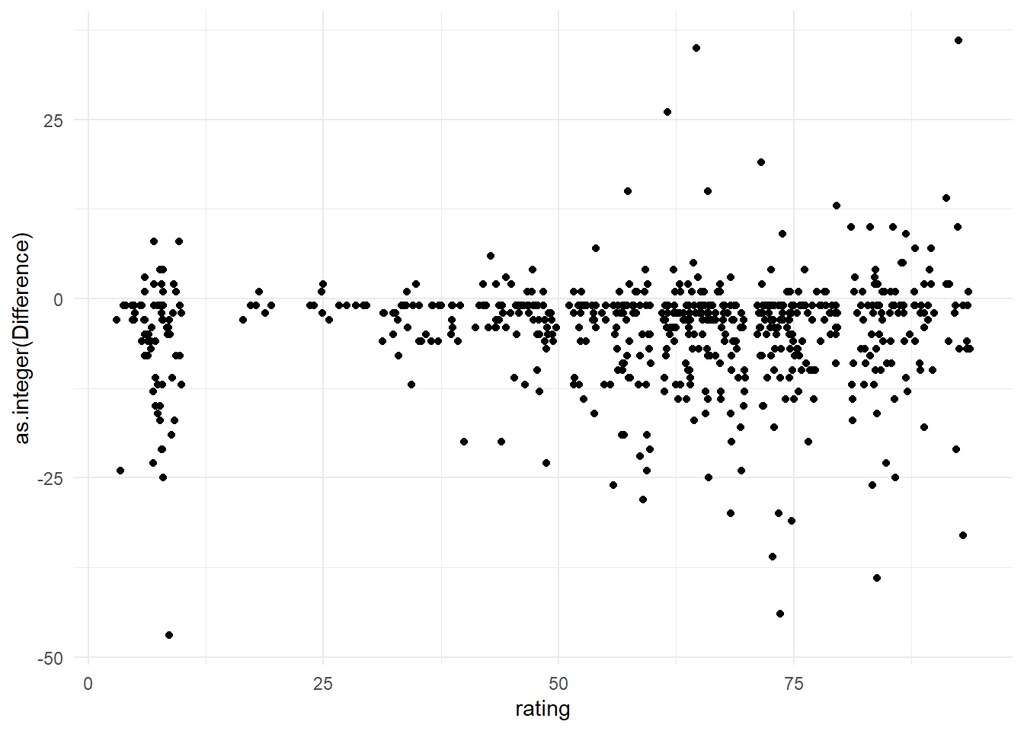

```r
wrestler_ratings %>%
  ggplot(aes(rating, as.integer(Difference)))+
  geom_point()+
  theme_minimal()
```

This attempt was close to solving for the zero issue. It added back in the zeros in the numbers identified above, but also added a zero after every other number in a rating. Rather than including the true zero, it used a zero as a spacer.

```r
wrestler_ratings_2 <-  purrr::map_df(698, ~{

  tryCatch({
    initial_read <- read_html(all_tables$wrestler_links[.x]) %>%
      html_elements("td img[src*='note']") %>%
      html_attr("src") %>%
      stringr::str_extract(., "[0-9,]+") %>%
      gsub(",", "", .)

    initial_read[is.na(initial_read)] <- "."

    rating <- as.numeric(paste(initial_read, collapse = ""))

    result <- all_tables[.x, ]

    result$rating <- rating

    result
  }, error = function(e){
    output <- all_tables[.x, ]
    output$rating <- NA
    output
  })

})
```

This attempt finally included true zeros without using a zero as a spacer as well. This resulted in true ratings pulled from the images that indicated wrestler rating in individual profiles, except an added zero after the decimal…

```r
wrestler_ratings_real <- purrr::map_df(1:nrow(all_tables), ~{

  tryCatch({
    initial_read <- read_html(all_tables$wrestler_links[.x]) %>%
      html_elements("td img[src*='note']") %>%
      html_attr("src") %>%
      stringr::str_extract(., "[0-9,]+") %>%
      gsub(",", "", .)

    initial_read[is.na(initial_read)] <- "."

    rating <- as.numeric(gsub("(?<=[0-9])0(?!\\.)", "", paste(initial_read, collapse = ""), perl = TRUE))

    result <- all_tables[.x, ]

    result$rating <- rating

    result
  }, error = function(e){
    output <- all_tables[.x, ]
    output$rating <- NA
    output
  })

})
```

Now we take away that included zero after each decimal and we have the real rating!

```r
wrestler_ratings_real$ratings2 <- as.character(wrestler_ratings_real$rating)
 wrestler_ratings_real$ratings2 <- gsub("(?<=\\.)(.)", "",wrestler_ratings_real$ratings2, perl = TRUE)
wrestler_ratings_real$ratings2 <- as.numeric(wrestler_ratings_real$ratings2)
```

Now we take out the link column and the rating with a zero after the decimal column. We will also rename tye true rating column to reflect it’s true nature and create the difference column to be an integer for later use. Let’s make thsi all it’s own table.

```r
wrestler_table_final <- wrestler_ratings_real[ ,c(1:7,10)]

wrestler_table_final <- wrestler_table_final %>%
  rename(Rating_True = ratings2)

wrestler_table_final$Difference <- as.integer(wrestler_table_final$Difference)
```

Here we run a linear model and a robust linear model to see if Win/Loss difference is a predictor of a wrestlers rating. We also create a scatterplot of rating and difference to visualize this hypothesis.

```r
model <- lm(Rating_True ~ Difference, wrestler_table_final)
summary(model)
```

```
##
## Call:
## lm(formula = Rating_True ~ Difference, data = wrestler_table_final)
##
## Residuals:
##    Min     1Q Median     3Q    Max
## -54.67 -10.40   1.54  11.51  33.26
##
## Coefficients:
##             Estimate Std. Error t value Pr(>|t|)
## (Intercept) 64.06875    0.76262  84.011   <2e-16 ***
## Difference  -0.13218    0.08679  -1.523    0.128
## ---
## Signif. codes:  0 '***' 0.001 '**' 0.01 '*' 0.05 '.' 0.1 ' ' 1
##
## Residual standard error: 16.71 on 637 degrees of freedom
##   (110 observations deleted due to missingness)
## Multiple R-squared:  0.003628,   Adjusted R-squared:  0.002064
## F-statistic: 2.319 on 1 and 637 DF,  p-value: 0.1283
```

```r
model_2 <- rlm(Rating_True ~ Difference, wrestler_table_final)
summary(model_2)
```

```
##
## Call: rlm(formula = Rating_True ~ Difference, data = wrestler_table_final)
## Residuals:
##      Min       1Q   Median       3Q      Max
## -55.7194 -11.3946   0.6824  10.4916  31.6389
##
## Coefficients:
##             Value   Std. Error t value
## (Intercept) 65.0865  0.8046    80.8949
## Difference  -0.1155  0.0916    -1.2619
##
## Residual standard error: 16.01 on 637 degrees of freedom
##   (110 observations deleted due to missingness)
```

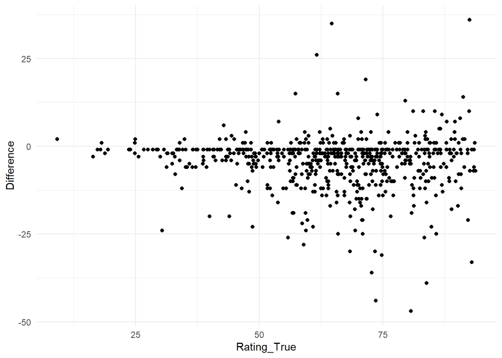

```r
wrestler_table_final %>%
  ggplot(aes(Rating_True, Difference))+
  geom_point()+
  theme_minimal()
```

Since we cannot use Difference as a predictor of rating, I decided to use an optimize technique. I wanted to know who make sense to wrestle as long as they have a negative win/loss difference (more losses than wins) and a rating of at least 80. Also, I want them to have wrestled at least 50 times on PPV.

```r
DiffLimit <- -1
RateLimit <- 80
MatchLimit <- 50
wrestler_table_final %>%
  filter(Difference <= DiffLimit & Rating_True > RateLimit & as.integer(Matches) >= MatchLimit) %>%
  mutate(optimum = Rating_True + Difference)
```

```
##    Rank           Wrestler Wins Draws Defeats Difference Matches Rating_True
## 1   244         Kurt Angle   43     0      44         -1      87      90.732
## 2   452    Bryan Danielson   38     2      40         -2      80      90.882
## 3   453        Rob Van Dam   27     0      29         -2      56      84.354
## 4   655        Becky Lynch   25     0      31         -6      56      86.750
## 5   656     Eddie Guerrero   22     0      28         -6      50      93.460
## 6   683     Shawn Michaels   53     7      60         -7     120      93.400
## 7   722            CM Punk   36     2      45         -9      83      88.394
## 8   735        Kevin Owens   28     0      38        -10      66      89.772
## 9   766          AJ Styles   27     2      39        -12      68      90.890
## 10  791     Christian Cage   41     0      55        -14      96      85.734
## 11  815         Mick Foley   20     3      38        -18      61      88.880
## 12  826 Claudio Castagnoli   31     1      52        -21      84      92.262
## 13  830      John Hennigan   25     0      48        -23      73      84.848
## 14  838            Natalya   23     1      48        -25      72      85.794
```

[output cut: 23 more lines]